# **AASD 4015 - Group Project 1**

### **Member:** 1. Chun Cheong Mak (101409987) 2. Hei Yuet Lee (101409639)

Pneumonia is a lung disease that inflames the air sacs in the lungs and could be fatal to children and the elderly. Nowadays, medical application of deep learning is popular to relieve the problem of shortage of doctors.

In this project, two CNN models will be built for classifying the healthy lungs and infected lungs. The first model is built from sketch and the second model is built by transform learning of a pre-trained model.

After building the models, we will perform fine-tuning to the models by different techniques, like early stopping, learning rate schedule, unfreezing pretrained layers, etc.

The main reference of this project is the **chapter08_intro-to-dl-for-computer-vision.ipynb**, which is also the implementation of the code in Chapter 8 of Deep Learning with Python (2nd edition, Fancois Chollet) by **Prof. Ran Feldesh**.

The main takeaways from this notebook:

- Preprocess and visualize the dataset
- Build two baseline models and fine-tune them
- Data augmnentation, dropout, adding layers, changing optimizer, early stopping, learning rate schedule and unfreezing pretrained layers are used
- Evaluate the train accuracy, validation accuracy, test accuracy of models before and after fine-tuning
- Evaluate the train loss, validation loss, test loss of models before and after fine-tuning

### **Data - Chest X-Ray Images (Pneumonia)**

The link of Kaggle: https://www.kaggle.com/datasets/paultimothymooney/chest-xray-pneumonia

### **Table of Contents:**

1. Data Preprocessing  
2. Data Visualization  
3. Model 1  
4. Model 2: Fine-tune the Model 1  
5. VGG16 Model 1: Build a CNN Model by Transfer Learning  
6. VGG16 Model 2: Fine-tune the VGG16 Model 1  
7. VGG16 Model 3: Fine-tune the VGG16 Model 2 with Learning Rate Schedule and Unfreezing Pretrained Layers  
8. Summary

### **Setup**

```python
#!pip install tensorflow==2.8.3
```

```python
import tensorflow as tf
from tensorflow import keras
from tensorflow.keras import layers
from tensorflow.keras.utils import image_dataset_from_directory
import matplotlib.pyplot as plt
import os, shutil, pathlib
import random
```

```python
tf.__version__
```

```
'2.8.3'
```

```python
#from google.colab import drive
#drive.mount('/content/gdrive')
```

```python
#%cd /content/gdrive/MyDrive/AASD-4015/
```

[output not shown]

### **1. Data Preprocessing**

After downloading and unzipping the data, there are 3 folders in chest_xray: train, test and val. There are 2 folders in each of these 3 folders: NORMAL and PNEUMONIA. To avoid data inbalance, we need to check the total number of images in NORMAL and PNEUMONIA as follows:

```python
test_normal_file_list = os.listdir('chest_xray/test/NORMAL')
test_pneumonia_file_list = os.listdir('chest_xray/test/PNEUMONIA')
train_normal_file_list = os.listdir('chest_xray/train/NORMAL')
train_pneumonia_file_list = os.listdir('chest_xray/train/PNEUMONIA')
val_normal_file_list = os.listdir('chest_xray/val/NORMAL')
val_pneumonia_file_list = os.listdir('chest_xray/val/PNEUMONIA')
```

Obviously, there is a problem of data imbalance. The total number of normal case and pneumonia case is 1585 and 4283 respectively.

```python
print('Total number of normal case:', len(test_normal_file_list)+len(train_normal_file_list)+len(val_normal_file_list))
print('Total number of pneumonia case:', len(test_pneumonia_file_list)+len(train_pneumonia_file_list)+len(val_pneumonia_file_list))
```

```
Total number of normal case: 1585
Total number of pneumonia case: 4283
```

To deal with this problem, 2 new folders (normal, pneumonia) are created to stored all the images of normal case and pneumonia case respectively and images are copied to the corresponding folders as follows:

```python
for folder in ['normal', 'pneumonia']:
    os.makedirs(f'chest_xray/{folder}')
```

```python
for file in test_normal_file_list:
    shutil.copyfile(src=f'chest_xray/test/NORMAL/{file}', dst=f'chest_xray/normal/{file}')
for file in test_pneumonia_file_list:
    shutil.copyfile(src=f'chest_xray/test/PNEUMONIA/{file}', dst=f'chest_xray/pneumonia/{file}')
for file in train_normal_file_list:
    shutil.copyfile(src=f'chest_xray/train/NORMAL/{file}', dst=f'chest_xray/normal/{file}')
for file in train_pneumonia_file_list:
    shutil.copyfile(src=f'chest_xray/train/PNEUMONIA/{file}', dst=f'chest_xray/pneumonia/{file}')
for file in val_normal_file_list:
    shutil.copyfile(src=f'chest_xray/val/NORMAL/{file}', dst=f'chest_xray/normal/{file}')
for file in val_pneumonia_file_list:
    shutil.copyfile(src=f'chest_xray/val/PNEUMONIA/{file}', dst=f'chest_xray/pneumonia/{file}')
```

```python
normal_file_list = os.listdir('chest_xray/normal')
pneumonia_file_list = os.listdir('chest_xray/pneumonia')
len(normal_file_list), len(pneumonia_file_list)
```

```
(1585, 4276)
```

After that, the number of images in these two folders is reduced to 1500 by randomly removing appropriate number and the total number of normal case and pneumonia is the same.

```python
random.seed(0)
extra_normal_file = random.sample(normal_file_list, len(normal_file_list) - 1500)
extra_pneumonia_file = random.sample(pneumonia_file_list, len(pneumonia_file_list) - 1500)
for file in extra_normal_file:
    os.remove(f'chest_xray/normal/{file}')
for file in extra_pneumonia_file:
    os.remove(f'chest_xray/pneumonia/{file}')
```

```python
normal_file_list = os.listdir('chest_xray/normal')
pneumonia_file_list = os.listdir('chest_xray/pneumonia')
len(normal_file_list), len(pneumonia_file_list)
```

```
(1500, 1500)
```

Make a new folder called project1 to be the main directory to store train, test and validation data for building our models in coming tasks. The function of generating train, test and validation set here is based on the **chapter08_intro-to-dl-for-computer-vision.ipynb** with some modification.

```python
if not os.path.exists('project1'):
    os.makedirs('project1')
```

```python
def make_subset(subset_name, start_index, end_index):
    for category in ['normal', 'pneumonia']:
        os.makedirs(f'project1/{subset_name}/{category}')
        for file in os.listdir(f'chest_xray/{category}')[start_index:end_index]:
            shutil.copyfile(src=f'chest_xray/{category}/{file}',
                            dst=f'project1/{subset_name}/{category}/{file}')
```

The ratio of train, validation and test is 0.8: 0.1: 0.1.

```python
make_subset('train', start_index=0, end_index=1200)
make_subset('validation', start_index=1200, end_index=1350)
make_subset('test', start_index=1350, end_index=1500)
```

Finally, three `tf.data.Dataset` (train_dataset, validation_dataset and test_dataset) with batch size 32 and image size (180, 180) are generated by `tf.keras.utils.image_dataset_from_directory` by following the setting in **chapter08_intro-to-dl-for-computer-vision.ipynb**.

```python
train_dataset = image_dataset_from_directory(
    'project1/train',
    image_size=(180, 180),
    batch_size=32)
validation_dataset = image_dataset_from_directory(
    'project1/validation',
    image_size=(180, 180),
    batch_size=32)
test_dataset = image_dataset_from_directory(
    'project1/test',
    image_size=(180, 180),
    batch_size=32)
```

```
Found 2400 files belonging to 2 classes.
Found 300 files belonging to 2 classes.
Found 300 files belonging to 2 classes.
```

```python
class_names = train_dataset.class_names
class_names
```

```
['normal', 'pneumonia']
```

### **2. Data Visualization**

Take one batch from train_dataset and 12 images from that batch to visualize the x-ray photos of normal lungs and lungs with pneumonia. From the below visualization, many white spots can be observed on x-ray of pneumonia. For normal lungs, the x-ray can clearly show the outline of the lung and bones.

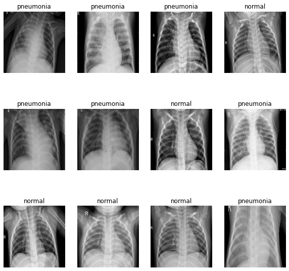

```python
plt.figure(figsize=(10,10))
for image_batch, label_batch in train_dataset.take(1):
    for i in range(12):
        ax = plt.subplot(3, 4, i+1)
        plt.imshow(image_batch[i].numpy().astype('uint8'))
        plt.title(class_names[label_batch[i]])
        plt.axis('off')
```

### **3. Model 1**

The architecture and compilation of the model 1 are taken from **chapter08_intro-to-dl-for-computer-vision.ipynb**.  
This is also the architecture on the page 216 of Chapter 8 of Deep Learning with Python (2nd edition, Fancois Chollet).

```python
inputs = keras.Input(shape=(180, 180, 3))
x = layers.Rescaling(1./255)(inputs)
x = layers.Conv2D(filters=32, kernel_size=3, activation="relu")(x)
x = layers.MaxPooling2D(pool_size=2)(x)
x = layers.Conv2D(filters=64, kernel_size=3, activation="relu")(x)
x = layers.MaxPooling2D(pool_size=2)(x)
x = layers.Conv2D(filters=128, kernel_size=3, activation="relu")(x)
x = layers.MaxPooling2D(pool_size=2)(x)
x = layers.Conv2D(filters=256, kernel_size=3, activation="relu")(x)
x = layers.MaxPooling2D(pool_size=2)(x)
x = layers.Conv2D(filters=256, kernel_size=3, activation="relu")(x)
x = layers.Flatten()(x)
outputs = layers.Dense(1, activation="sigmoid")(x)
model = keras.Model(inputs=inputs, outputs=outputs)
```

```python
model.summary()
```

```
Model: "model_11"
_________________________________________________________________
 Layer (type)                Output Shape              Param #
=================================================================
 input_12 (InputLayer)       [(None, 180, 180, 3)]     0

 rescaling_11 (Rescaling)    (None, 180, 180, 3)       0

 conv2d_55 (Conv2D)          (None, 178, 178, 32)      896

 max_pooling2d_44 (MaxPoolin  (None, 89, 89, 32)       0
 g2D)

 conv2d_56 (Conv2D)          (None, 87, 87, 64)        18496

 max_pooling2d_45 (MaxPoolin  (None, 43, 43, 64)       0
 g2D)

 conv2d_57 (Conv2D)          (None, 41, 41, 128)       73856

 max_pooling2d_46 (MaxPoolin  (None, 20, 20, 128)      0
 g2D)

 conv2d_58 (Conv2D)          (None, 18, 18, 256)       295168

 max_pooling2d_47 (MaxPoolin  (None, 9, 9, 256)        0
 g2D)

 conv2d_59 (Conv2D)          (None, 7, 7, 256)         590080

 flatten_11 (Flatten)        (None, 12544)             0

 dense_32 (Dense)            (None, 1)                 12545

=================================================================
Total params: 991,041
Trainable params: 991,041
Non-trainable params: 0
_________________________________________________________________
```

Make a folder to save the model after training.

```python
if not os.path.exists('saved_model'):
    os.makedirs('saved_model')
```

```python
model.compile(loss="binary_crossentropy",
              optimizer="rmsprop",
              metrics=["accuracy"])
```

```python
callbacks = [
    keras.callbacks.ModelCheckpoint(
        filepath="saved_model/model_1.h5",
        save_best_only=True,
        monitor="val_loss")
]
```

```python
history = model.fit(
    train_dataset,
    epochs=30,
    validation_data=validation_dataset,
    callbacks=callbacks)
```

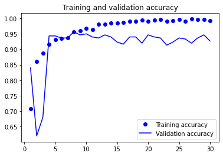

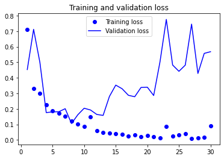

```python
import matplotlib.pyplot as plt
accuracy = history.history["accuracy"]
val_accuracy = history.history["val_accuracy"]
loss = history.history["loss"]
val_loss = history.history["val_loss"]
epochs = range(1, len(accuracy) + 1)
plt.plot(epochs, accuracy, "bo", label="Training accuracy")
plt.plot(epochs, val_accuracy, "b", label="Validation accuracy")
plt.title("Training and validation accuracy")
plt.legend()
plt.figure()
plt.plot(epochs, loss, "bo", label="Training loss")
plt.plot(epochs, val_loss, "b", label="Validation loss")
plt.title("Training and validation loss")
plt.legend()
plt.show()
```

From the above evaluation, the over-fitting occurs at epoch 8. The validation loss decreases before 8 epochs. After 8 epochs, the validation loss increases largely and the validation accuracy can no longer increase significantly.  
The model of epoch 8 is saved and used to predict the test_dataset. The test accuracy and loss is 0.963 and 0.106 respectively.

```python
test_model = keras.models.load_model("saved_model/model_1.h5")
test_loss, test_acc = test_model.evaluate(test_dataset)
print(f"Test accuracy: {test_acc:.3f}")
print(f"Test loss: {test_loss:.3f}")
```

```
Test accuracy: 0.963
Test loss: 0.106
```

### **4. Model 2: Fine-tune the Model 1**

To fine-tune the above Model 1, we made following modification and train a Model 2:

- Data augmentation
- Add more `Dense` layer after `Flatten` layer
- Add more `Dropout` layer after `Flatten` layer
- Use `adam` optimizer
- Introduce early stopping in callbacks

Overfitting may be caused by using too few samples to train. The following data augmentation will filp the images horizontally and change the contrast of the images randomly. This augmentation will generate more training data from existing data and relieve the problem of over-fitting.

```python
data_augmentation = keras.Sequential(
    [
        layers.RandomFlip("horizontal"),
        layers.RandomContrast(0.2)
    ]
)
```

Two `Dense` layers with 64 and 16 neurons are added after `Flatten` layer to increase the accuracy. At the same time, three `Dropout` layers with 0.5 are added to avoid over-fitting.

```python
inputs = keras.Input(shape=(180, 180, 3))
x = data_augmentation(inputs)
x = layers.Rescaling(1./255)(x)
x = layers.Conv2D(filters=32, kernel_size=3, activation="relu")(x)
x = layers.MaxPooling2D(pool_size=2)(x)
x = layers.Conv2D(filters=64, kernel_size=3, activation="relu")(x)
x = layers.MaxPooling2D(pool_size=2)(x)
x = layers.Conv2D(filters=128, kernel_size=3, activation="relu")(x)
x = layers.MaxPooling2D(pool_size=2)(x)
x = layers.Conv2D(filters=256, kernel_size=3, activation="relu")(x)
x = layers.MaxPooling2D(pool_size=2)(x)
x = layers.Conv2D(filters=256, kernel_size=3, activation="relu")(x)
x = layers.Flatten()(x)
x = layers.Dropout(0.5)(x)
x = layers.Dense(64, activation="relu")(x)
x = layers.Dropout(0.5)(x)
x = layers.Dense(16, activation="relu")(x)
x = layers.Dropout(0.5)(x)
outputs = layers.Dense(1, activation="sigmoid")(x)
model = keras.Model(inputs=inputs, outputs=outputs)
```

`adam` combines the ideas of momentum optimization and RMSProp and the performance should be better or almost the same.

```python
model.compile(loss="binary_crossentropy",
              optimizer="adam",
              metrics=["accuracy"])
```

Early stopping with 10 patience is added and the training will stop after 10 epochs without improvement in validation loss. It is used to stop the training when over-fitting happens.

```python
early_stopping_cb = keras.callbacks.EarlyStopping(patience=10, restore_best_weights=True)
```

```python
callbacks = [
    keras.callbacks.ModelCheckpoint(
        filepath="saved_model/model_2.h5",
        save_best_only=True,
        monitor="val_loss"),
        early_stopping_cb
]

history = model.fit(
    train_dataset,
    epochs=80,
    validation_data=validation_dataset,
    callbacks=callbacks)
```

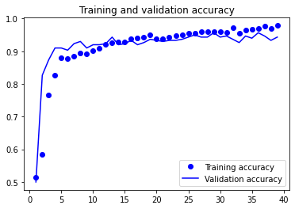

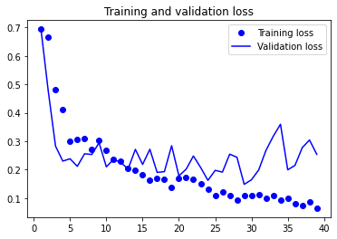

```python
import matplotlib.pyplot as plt
accuracy = history.history["accuracy"]
val_accuracy = history.history["val_accuracy"]
loss = history.history["loss"]
val_loss = history.history["val_loss"]
epochs = range(1, len(accuracy) + 1)
plt.plot(epochs, accuracy, "bo", label="Training accuracy")
plt.plot(epochs, val_accuracy, "b", label="Validation accuracy")
plt.title("Training and validation accuracy")
plt.legend()
plt.figure()
plt.plot(epochs, loss, "bo", label="Training loss")
plt.plot(epochs, val_loss, "b", label="Validation loss")
plt.title("Training and validation loss")
plt.legend()
plt.show()
```

```python
test_model = keras.models.load_model("saved_model/model_2.h5")
test_loss, test_acc = test_model.evaluate(test_dataset)
print(f"Test accuracy: {test_acc:.3f}")
print(f"Test loss: {test_loss:.3f}")
```

```
Test accuracy: 0.973
Test loss: 0.091
```

### **5. VGG16 Model 1: Build a CNN Model by Transfer Learning**

The architecture and compilation of the below transfer learning model are taken from **chapter08_intro-to-dl-for-computer-vision.ipynb**.  
The VGG convolutional base was instantiated and freezed.

```python
conv_base = keras.applications.vgg16.VGG16(
    weights='imagenet',
    include_top=False,
    input_shape=(180, 180, 3))
```

```python
conv_base.summary()
```

```
Model: "vgg16"
_________________________________________________________________
 Layer (type)                Output Shape              Param #
=================================================================
 input_1 (InputLayer)        [(None, 180, 180, 3)]     0

 block1_conv1 (Conv2D)       (None, 180, 180, 64)      1792

 block1_conv2 (Conv2D)       (None, 180, 180, 64)      36928

 block1_pool (MaxPooling2D)  (None, 90, 90, 64)        0

 block2_conv1 (Conv2D)       (None, 90, 90, 128)       73856

 block2_conv2 (Conv2D)       (None, 90, 90, 128)       147584

 block2_pool (MaxPooling2D)  (None, 45, 45, 128)       0

 block3_conv1 (Conv2D)       (None, 45, 45, 256)       295168

 block3_conv2 (Conv2D)       (None, 45, 45, 256)       590080

 block3_conv3 (Conv2D)       (None, 45, 45, 256)       590080

 block3_pool (MaxPooling2D)  (None, 22, 22, 256)       0

 block4_conv1 (Conv2D)       (None, 22, 22, 512)       1180160

 block4_conv2 (Conv2D)       (None, 22, 22, 512)       2359808

 block4_conv3 (Conv2D)       (None, 22, 22, 512)       2359808

 block4_pool (MaxPooling2D)  (None, 11, 11, 512)       0

 block5_conv1 (Conv2D)       (None, 11, 11, 512)       2359808

 block5_conv2 (Conv2D)       (None, 11, 11, 512)       2359808

 block5_conv3 (Conv2D)       (None, 11, 11, 512)       2359808

 block5_pool (MaxPooling2D)  (None, 5, 5, 512)         0

=================================================================
Total params: 14,714,688
Trainable params: 14,714,688
Non-trainable params: 0
_________________________________________________________________
```

```python
conv_base.trainable = False
```

```python
inputs = keras.Input(shape=(180, 180, 3))
x = keras.applications.vgg16.preprocess_input(inputs)
x = conv_base(x)
x = layers.Flatten()(x)
x = layers.Dense(256)(x)
#x = layers.Dropout(0.5)(x)
#x = layers.Dense(128)(x)
#x = layers.Dropout(0.5)(x)
#x = layers.Dense(64)(x)
x = layers.Dropout(0.5)(x)
outputs = layers.Dense(1, activation='sigmoid')(x)
model_vgg = keras.Model(inputs, outputs)
```

```python
model_vgg.compile(loss='binary_crossentropy',
                  optimizer='rmsprop',
                  metrics=["accuracy"])
```

```python
callbacks = [
    keras.callbacks.ModelCheckpoint(
        filepath="saved_model/model_vgg_1.h5",
        save_best_only=True,
        monitor="val_loss")
]
```

```python
history = model_vgg.fit(
    train_dataset,
    epochs=20,
    validation_data=validation_dataset,
    callbacks=callbacks)
```

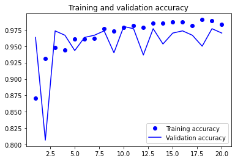

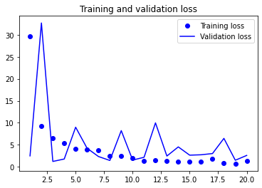

```python
import matplotlib.pyplot as plt
accuracy = history.history["accuracy"]
val_accuracy = history.history["val_accuracy"]
loss = history.history["loss"]
val_loss = history.history["val_loss"]
epochs = range(1, len(accuracy) + 1)
plt.plot(epochs, accuracy, "bo", label="Training accuracy")
plt.plot(epochs, val_accuracy, "b", label="Validation accuracy")
plt.title("Training and validation accuracy")
plt.legend()
plt.figure()
plt.plot(epochs, loss, "bo", label="Training loss")
plt.plot(epochs, val_loss, "b", label="Validation loss")
plt.title("Training and validation loss")
plt.legend()
plt.show()
```

```python
test_model = keras.models.load_model("saved_model/model_vgg_1.h5")
test_loss, test_acc = test_model.evaluate(test_dataset)
print(f"Test accuracy: {test_acc:.3f}")
print(f"Test loss: {test_loss:.3f}")
```

```
Test accuracy: 0.967
Test loss: 2.222
```

From the above evaluation, the validation loss keeps constant until epoch 10 and starts to slightly increase. On the other hand, the training accuracy keeps increasing steadily.  
The model of epoch 3 is saved and used to predict the test_dataset. The test accuracy and loss is 0.967 and 2.222 respectively.  
Compared to the previous model, the test loss of VGG model is relatively high.

### **6. VGG16 Model 2: Fine-tune the VGG16 Model 1**

To fine-tune the above VGG16 model 1, we made following modification:

- Data augmentation
- Use `adam` optimizer
- Introduce early stopping in callbacks

The reasons of using above modification are same as the reasons mentioned in Section 4.

```python
data_augmentation = keras.Sequential(
    [
        layers.RandomFlip("horizontal"),
        layers.RandomContrast(0.2)
    ]
)
```

```python
inputs = keras.Input(shape=(180, 180, 3))
x = data_augmentation(inputs)
x = keras.applications.vgg16.preprocess_input(x)
x = conv_base(x)
x = layers.Flatten()(x)
x = layers.Dense(256)(x)
#x = layers.Dropout(0.5)(x)
#x = layers.Dense(128)(x)
#x = layers.Dropout(0.5)(x)
#x = layers.Dense(64)(x)
x = layers.Dropout(0.5)(x)
outputs = layers.Dense(1, activation='sigmoid')(x)
model_vgg = keras.Model(inputs, outputs)
```

```python
model_vgg.compile(loss='binary_crossentropy',
                  optimizer='adam',
                  metrics=["accuracy"])
```

```python
early_stopping_cb = keras.callbacks.EarlyStopping(patience=10, restore_best_weights=True)
```

```python
callbacks = [
    keras.callbacks.ModelCheckpoint(
        filepath="saved_model/model_vgg_2.h5",
        save_best_only=True,
        monitor="val_loss"),
        early_stopping_cb
]
```

```python
history = model_vgg.fit(
    train_dataset,
    epochs=80,
    validation_data=validation_dataset,
    callbacks=callbacks)
```

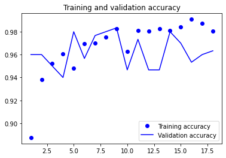

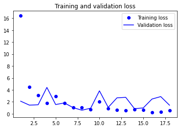

```python
import matplotlib.pyplot as plt
accuracy = history.history["accuracy"]
val_accuracy = history.history["val_accuracy"]
loss = history.history["loss"]
val_loss = history.history["val_loss"]
epochs = range(1, len(accuracy) + 1)
plt.plot(epochs, accuracy, "bo", label="Training accuracy")
plt.plot(epochs, val_accuracy, "b", label="Validation accuracy")
plt.title("Training and validation accuracy")
plt.legend()
plt.figure()
plt.plot(epochs, loss, "bo", label="Training loss")
plt.plot(epochs, val_loss, "b", label="Validation loss")
plt.title("Training and validation loss")
plt.legend()
plt.show()
```

```python
test_model = keras.models.load_model("saved_model/model_vgg_2.h5")
test_loss, test_acc = test_model.evaluate(test_dataset)
print(f"Test accuracy: {test_acc:.3f}")
print(f"Test loss: {test_loss:.3f}")
```

```
Test accuracy: 0.970
Test loss: 1.974
```

From the above evaluation, the validation loss decreases before the 8th epoch. After that, the validation loss slightly increases and there is a drop in validation accuracy.  
The model of epoch 8 is saved and used to predict the test_dataset. The test accuracy and loss is 0.970 and 1.974 respectively. An improvement in test loss can be found after the fine-tuning.

### **7. VGG16 Model 3: Fine-tune the VGG16 Model 2 with Learning Rate Schedule and Unfreezing Pretrained Layers**

To futher fine-tune the VGG16 Model 2, we made following modification:

- Freeze the base layer until the forth from the end
- Introduce learning rate scheduler

Below exponential decay function is taken from **Chapter 11 of Hands-On Machine Learning with Scikit-Learn, Keras, and TensorFlow (3nd edition, Aurélien Géron)**.

```python
conv_base.trainable = True
for layer in conv_base.layers[:-4]:
    layer.trainable = False
```

```python
def exponential_decay(lr0, s):
    def exponential_decay_fn(epoch):
        return lr0 * 0.1**(epoch / s)
    return exponential_decay_fn
```

To achieve the a better result, exponential scheduling is used to adjust the learning rate during the training. The learning rate will gradually drop by a factor of 10 every s steps.  
In order to prevent from overfitting very quickly, the initial learning rate will be set to very small.

```python
exponential_decay_fn = exponential_decay(lr0=0.00001, s=80)
lr_scheduler = keras.callbacks.LearningRateScheduler(exponential_decay_fn)
```

```python
model_vgg.compile(loss="binary_crossentropy",
              optimizer="adam",
              metrics=["accuracy"])
```

```python
callbacks = [
    keras.callbacks.ModelCheckpoint(
        filepath="saved_model/model_vgg_3.h5",
        save_best_only=True,
        monitor="val_loss"),
        lr_scheduler,
        early_stopping_cb
]
```

```python
history = model_vgg.fit(
    train_dataset,
    epochs=80,
    validation_data=validation_dataset,
    callbacks=callbacks)
```

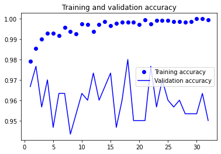

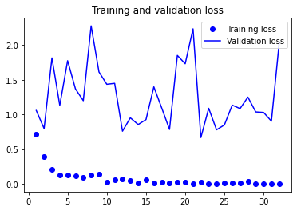

```python
import matplotlib.pyplot as plt
accuracy = history.history["accuracy"]
val_accuracy = history.history["val_accuracy"]
loss = history.history["loss"]
val_loss = history.history["val_loss"]
epochs = range(1, len(accuracy) + 1)
plt.plot(epochs, accuracy, "bo", label="Training accuracy")
plt.plot(epochs, val_accuracy, "b", label="Validation accuracy")
plt.title("Training and validation accuracy")
plt.legend()
plt.figure()
plt.plot(epochs, loss, "bo", label="Training loss")
plt.plot(epochs, val_loss, "b", label="Validation loss")
plt.title("Training and validation loss")
plt.legend()
plt.show()
```

```python
test_model = keras.models.load_model("saved_model/model_vgg_3.h5")
test_loss, test_acc = test_model.evaluate(test_dataset)
print(f"Test accuracy: {test_acc:.3f}")
print(f"Test loss: {test_loss:.3f}")
```

```
Test accuracy: 0.970
Test loss: 1.064
```

From the above evaluation, the validation loss decreases before the 22nd epoch. After that, the validation loss slightly increases and there is a drop in validation accuracy. Overall the training accuracy increases gradually.  
The model of epoch 22 is saved and used to predict the test dataset. The test accuracy is 0.970, while the test loss improved from 1.974 to 1.064. An improvement in test loss can be found after the fine-tuning.

### **8. Summary**

The test accuracy and loss of Model 1 in Section 3 is 0.963 and 0.106 respectively.  
The test accuracy and loss of Model 2 in Section 4 is 0.973 and 0.091 respectively.  
The summary of all models using transfer learning:

| VGG16 Model | Data Augmentation | Early Stopping | Freeze layers | Optimizer | Initial Learning Rate | Learning rate schedule | Test Accuracy | Test loss | |-----|-----|-----|-----|-----|-----|-----|-----|-----| | 1 | No | No | All | RMSprop | 0.001 | No | 0.967 | 2.222 | | 2 | Yes | Yes | All | Adam | 0.001 | No | 0.970 | 1.974 | | 3 | Yes | Yes | Freeze until the 4th from last | Adam | 1e-5 | Yes | 0.970 | 1.064 |

The Model 2 in Section 4 outperforms all the models using transfer learning. The possible reason is that VGG16 is already an older model. Changing to other newer pretrained models may improve the performance in transfer learning.